# Spatial Inequality in Internet Access 2000 – 2020

https://github.com/XiaofengLi1315/Xiaofeng-Li-Advanced-Topics-for-Urban-Analytics.git

# 1. Introduction

Internet access has expanded rapidly over the past two decades, reaching over 60% of the global population by 2020. Despite this growth, substantial inequalities in internet access persist across countries. Existing studies commonly explain these differences through economic development, infrastructure and urbanisation, but most assume countries are independent observations and overlook the spatial structure of internet inequality (Chinn & Fairlie, 2007). Neighbouring countries often share infrastructure systems, regional markets and policy environments; ignoring these spatial relationships may lead to biased estimates and an incomplete understanding of the global digital divide (Vicente & López, 2011).

This study examines the spatial characteristics of global internet inequality from 2000 to 2020 using spatial statistical and spatial econometric methods. Four research questions are addressed: (1) Does global internet access exhibit persistent spatial inequality? (2) Is there significant spatial autocorrelation in internet penetration? (3) How do economic development, electricity access and urbanisation influence internet access? (4) Do spatial econometric models better explain internet inequality than OLS?

# 2. Data collection and data cleaning

## 2.1 Data collection

Data for this study were obtained from the World Bank API using Python for the period 2000–2020. The dataset includes one dependent variable, internet access rate (IT.NET.USER.ZS), and three explanatory variables: GDP per capita (NY.GDP.PCAP.CD), electricity access rate (EG.ELC.ACCS.ZS) and urban population share (SP.URB.TOTL.IN.ZS). Only country-level observations were retained, while regional aggregates were excluded automatically during data processing.

The final dataset was organised as a country-year panel dataset using Pandas, providing the basis for descriptive analysis, regression modelling and spatial econometric analysis. As the analysis is conducted at the national level, the results may not fully capture inequalities within countries, particularly differences between urban and rural areas. In addition, limited data availability for some small island states may affect the representativeness of the results for those countries.

```python
import wbgapi as wb
import pandas as pd
import numpy as np
import matplotlib.pyplot as plt
import os
```

```python
# World Bank indicator code
INDICATORS = {
    'internet_users'     : 'IT.NET.USER.ZS',   # Dependent variable: Proportion of internet users (%)
    'gdp_per_capita'     : 'NY.GDP.PCAP.CD',   # Independent variable: GDP per capita (current USD)
    'electricity_access' : 'EG.ELC.ACCS.ZS',  # Independent variable: Electricity access (%)
    'urban_population'   : 'SP.URB.TOTL.IN.ZS' # Independent variable: Urban population (%)
}

START_YEAR = 2000
END_YEAR   = 2020

df_raw = wb.data.DataFrame(
    list(INDICATORS.values()),          # Indicator code list
    time=range(START_YEAR, END_YEAR + 1),  # Time range
    labels=True                         # Retain country names
)

print(f"Raw data download complete: {df_raw.shape}")
df_raw.head()
```

```
Raw data download complete: (1064, 23)
```

| economy | series | Country | Series | YR2000 | YR2001 | YR2002 | YR2003 | YR2004 | YR2005 | YR2006 | YR2007 | ... | YR2011 | YR2012 | YR2013 | YR2014 | YR2015 | YR2016 | YR2017 | YR2018 | YR2019 | YR2020 |
| --- | --- | --- | --- | --- | --- | --- | --- | --- | --- | --- | --- | --- | --- | --- | --- | --- | --- | --- | --- | --- | --- | --- |
| ZWE | IT.NET.USER.ZS | Zimbabwe | Individuals using the Internet (% of population) | 0.401434 | 0.799846 | 1.100000 | 1.800000 | 2.100000 | 2.400000 | 2.400000 | 3.000000 | ... | 8.400000 | 12.000000 | 15.500000 | 16.364740 | 22.742800 | 23.120001 | 24.400000 | 25.000000 | 26.588301 | 29.298565 |
| ZMB | IT.NET.USER.ZS | Zambia | Individuals using the Internet (% of population) | 0.191072 | 0.233130 | 0.477751 | 0.980483 | 1.100000 | 1.300000 | 1.600000 | 1.900000 | ... | 3.500000 | 4.100000 | 4.800000 | 6.500000 | 8.800000 | 10.300000 | 12.200000 | 14.299997 | 14.471900 | 14.645800 |
| YEM | IT.NET.USER.ZS | Yemen, Rep. | Individuals using the Internet (% of population) | 0.082500 | 0.090802 | 0.518796 | 0.604734 | 0.881223 | 1.048600 | 1.247824 | 5.010000 | ... | 14.905000 | 17.446501 | 20.000000 | 22.549999 | 24.085400 | 24.579201 | NaN | NaN | 17.490999 | NaN |
| PSE | IT.NET.USER.ZS | West Bank and Gaza | Individuals using the Internet (% of population) | 1.111306 | 1.836855 | 3.100092 | 4.130616 | 4.400905 | 16.004999 | 18.410000 | 21.176001 | ... | 41.080002 | 43.400000 | 46.599998 | 53.665200 | 56.700001 | 59.900002 | 63.299999 | 64.399994 | 70.622584 | 76.181602 |
| VIR | IT.NET.USER.ZS | Virgin Islands (U.S.) | Individuals using the Internet (% of population) | 13.815081 | 18.375766 | 27.494432 | 27.429073 | 27.377009 | 27.344320 | 27.332611 | 27.339336 | ... | 35.600000 | 40.547900 | 45.300000 | 50.070000 | 54.839137 | 59.608316 | 64.377494 | NaN | NaN | NaN |

5 rows × 23 columns

## 2.2 Data cleaning

During the data pre-processing stage, the raw World Bank data was cleaned and reorganised into a country-year panel format suitable for statistical analysis. Variable names were standardised, and regional aggregate observations were excluded. Countries with substantial missing data were removed, particularly where internet access observations were incomplete for more than 50% of the study period.

For the remaining missing values, linear interpolation was applied at the country level, while observations with persistent missing data were excluded from the analysis. The final dataset covers multiple countries between 2000 and 2020 and was used for descriptive statistics, regression analysis and spatial econometric modelling.

```python
#  Reset the index, converting `economy/series` to a standard column
df = df_raw.copy()
df = df.reset_index()   # New column:economy, series
df.columns.name = None

# Keep only the relevant columns (remove the ‘Series’ description column)
year_cols = [c for c in df.columns if c.startswith('YR')]   # ['YR2000', ..., 'YR2020']
keep_cols = ['economy', 'series', 'Country'] + year_cols
df = df[keep_cols]

# Wide table → Long table (melt)
df_long = df.melt(
    id_vars    = ['economy', 'series', 'Country'],
    value_vars = year_cols,
    var_name   = 'year_str',
    value_name = 'value'
)

#  Process the year column
df_long['year'] = df_long['year_str'].str.replace('YR', '', regex=False).astype(int)
df_long = df_long.drop(columns=['year_str'])

# Long table → Wide table (each indicator as a column)
df_wide = df_long.pivot_table(
    index   = ['economy', 'Country', 'year'],
    columns = 'series',
    values  = 'value'
).reset_index()

df_wide.columns.name = None

# Rename columns
df_wide = df_wide.rename(columns={
    'economy'            : 'country_code',
    'Country'            : 'country_name',
    'IT.NET.USER.ZS'     : 'internet_users',
    'NY.GDP.PCAP.CD'     : 'gdp_per_capita',
    'EG.ELC.ACCS.ZS'     : 'electricity_access',
    'SP.URB.TOTL.IN.ZS'  : 'urban_population'
})

# Final column order
df = df_wide[['country_code', 'country_name', 'year',
              'internet_users', 'gdp_per_capita',
              'electricity_access', 'urban_population']].copy()

df = df.sort_values(['country_code', 'year']).reset_index(drop=True)

print(f" Sorting complete")
print(f" dimension：{df.shape}")
print(f" Number of countries：{df['country_code'].nunique()}")
print(f" Year range：{df['year'].min()} – {df['year'].max()}")
df.head(10)
```

```
 Sorting complete
 dimension：(5565, 7)
 Number of countries：265
 Year range：2000 – 2020
```

|  | country_code | country_name | year | internet_users | gdp_per_capita | electricity_access | urban_population |
| --- | --- | --- | --- | --- | --- | --- | --- |
| 0 | ABW | Aruba | 2000 | 15.442823 | 20681.023027 | 91.7 | 65.354550 |
| 1 | ABW | Aruba | 2001 | 17.100000 | 20740.132583 | 100.0 | 65.335114 |
| 2 | ABW | Aruba | 2002 | 18.800000 | 21307.248251 | 100.0 | 65.282069 |
| 3 | ABW | Aruba | 2003 | 20.800000 | 21949.485996 | 100.0 | 65.198292 |
| 4 | ABW | Aruba | 2004 | 23.000000 | 23700.631990 | 100.0 | 65.088653 |
| 5 | ABW | Aruba | 2005 | 25.400000 | 24171.837133 | 100.0 | 64.958023 |
| 6 | ABW | Aruba | 2006 | 28.000000 | 24845.658484 | 100.0 | 64.811270 |
| 7 | ABW | Aruba | 2007 | 30.900000 | 26736.308944 | 100.0 | 64.653266 |
| 8 | ABW | Aruba | 2008 | 52.000000 | 28171.909401 | 100.0 | 64.488881 |
| 9 | ABW | Aruba | 2009 | 58.000000 | 25134.771230 | 100.0 | 64.322985 |

```python
# Check missing values for each variable
missing = df.isnull().mean().round(3) * 100
print("Missing value rates (%)：")
print(missing.to_string())

# Count of available countries each year
coverage = df.groupby('year')['internet_users'].count()
print(f"\nNumber of countries with internet data each year (min: {coverage.min()}, max: {coverage.max()})")
```

```
Missing value rates (%)：
country_code           0.0
country_name           0.0
year                   0.0
internet_users        15.7
gdp_per_capita         2.5
electricity_access     1.2
urban_population       0.0

Number of countries with internet data each year (min: 195, max: 237)
```

```python
os.makedirs('data', exist_ok=True)
df.to_csv('data/raw_internet_data.csv', index=False)
print(f"Data saved to data/raw_internet_data.csv")
print(f"Total rows: {len(df):,}, Columns: {df.shape[1]}")
df.describe().round(2)
```

```
Data saved to data/raw_internet_data.csv
Total rows: 5,565, Columns: 7
```

|  | year | internet_users | gdp_per_capita | electricity_access | urban_population |
| --- | --- | --- | --- | --- | --- |
| count | 5565.00 | 4693.00 | 5427.00 | 5498.00 | 5565.00 |
| mean | 2010.00 | 34.03 | 14051.68 | 79.94 | 57.51 |
| std | 6.06 | 29.55 | 22170.31 | 28.75 | 23.09 |
| min | 2000.00 | 0.00 | 109.59 | 0.80 | 8.04 |
| 25% | 2005.00 | 6.68 | 1449.04 | 65.10 | 38.47 |
| 50% | 2010.00 | 25.85 | 4693.79 | 97.30 | 56.41 |
| 75% | 2015.00 | 59.47 | 17524.51 | 100.00 | 76.47 |
| max | 2020.00 | 100.00 | 204263.80 | 100.00 | 100.00 |

```python
print("=" * 50)
print("Data Overview Before Cleaning")
print("=" * 50)
print(f"Total rows: {len(df):,}")
print(f"Number of countries: {df['country_code'].nunique()}")
print(f"Year range: {df['year'].min()} – {df['year'].max()}")
print()

# Missing value rates
missing_pct = df.isnull().mean().mul(100).round(1)
print("Missing value rates (%)：")
print(missing_pct[['internet_users','gdp_per_capita',
                    'electricity_access','urban_population']].to_string())
```

```
==================================================
Data Overview Before Cleaning
==================================================
Total rows: 5,565
Number of countries: 265
Year range: 2000 – 2020

Missing value rates (%)：
internet_users        15.7
gdp_per_capita         2.5
electricity_access     1.2
urban_population       0.0
```

```python
AGGREGATE_CODES = {
    'WLD','EAS','EAP','ECA','LAC','MNA','NAC','SAS','SSA','SSF',
    'HIC','LIC','LMC','UMC','LMY','MIC','OED',
    'ARB','CSS','CEB','EMU','EUU','FCS','HPC',
    'IBD','IBT','IDA','IDB','IDX','LDC','INX',
    'OSS','PSS','TSA','TSS','PRE','PST','TEA',
    'TEC','TLA','TMN','TSS','TLA','AFE','AFW'
}

before = df['country_code'].nunique()
df_clean = df[~df['country_code'].isin(AGGREGATE_CODES)].copy()
after   = df_clean['country_code'].nunique()

print(f"Aggregate regions filtered: {before} → {after} countries (removed {before - after})")
print(f"Remaining rows: {len(df_clean):,}")
df_clean.head()
```

```
Aggregate regions filtered: 265 → 223 countries (removed 42)
Remaining rows: 4,683
```

|  | country_code | country_name | year | internet_users | gdp_per_capita | electricity_access | urban_population |
| --- | --- | --- | --- | --- | --- | --- | --- |
| 0 | ABW | Aruba | 2000 | 15.442823 | 20681.023027 | 91.7 | 65.354550 |
| 1 | ABW | Aruba | 2001 | 17.100000 | 20740.132583 | 100.0 | 65.335114 |
| 2 | ABW | Aruba | 2002 | 18.800000 | 21307.248251 | 100.0 | 65.282069 |
| 3 | ABW | Aruba | 2003 | 20.800000 | 21949.485996 | 100.0 | 65.198292 |
| 4 | ABW | Aruba | 2004 | 23.000000 | 23700.631990 | 100.0 | 65.088653 |

```python
MISSING_THRESHOLD = 0.5

country_missing = (df_clean
                   .groupby('country_code')['internet_users']
                   .apply(lambda x: x.isnull().mean()))

drop_countries = country_missing[country_missing > MISSING_THRESHOLD].index.tolist()
df_clean = df_clean[~df_clean['country_code'].isin(drop_countries)].copy()

print(f"Countries with severe missing internet data (>{MISSING_THRESHOLD*100:.0f}%): {len(drop_countries)}")
print(f"Remaining countries: {df_clean['country_code'].nunique()}")
print(f"Remaining rows: {len(df_clean):,}")
```

```
Countries with severe missing internet data (>50%): 17
Remaining countries: 206
Remaining rows: 4,326
```

```python
TARGET_VARS = ['internet_users', 'gdp_per_capita',
               'electricity_access', 'urban_population']

df_clean = df_clean.sort_values(['country_code', 'year']).reset_index(drop=True)

missing_before = df_clean[TARGET_VARS].isnull().sum()

df_clean[TARGET_VARS] = (
    df_clean.groupby('country_code')[TARGET_VARS]
    .transform(lambda x: x.interpolate(method='linear', limit_direction='both'))
)

missing_after = df_clean[TARGET_VARS].isnull().sum()

print("Linear interpolation completed:")
print(f"{'Variable':<24} {'Before':>8} {'After':>8} {'Filled':>8}")
print("-" * 52)
for v in TARGET_VARS:
    filled = missing_before[v] - missing_after[v]
    print(f"{v:<24} {missing_before[v]:>8} {missing_after[v]:>8} {filled:>8}")
```

```
Linear interpolation completed:
Variable                   Before    After   Filled
----------------------------------------------------
internet_users                138        0      138
gdp_per_capita                 42       21       21
electricity_access              9        0        9
urban_population                0        0        0
```

```python
rows_before = len(df_clean)
df_clean = df_clean.dropna(subset=TARGET_VARS).reset_index(drop=True)

print(f"Removed remaining missing rows: {rows_before - len(df_clean)} rows")
print(f"Final dataset: {len(df_clean):,} rows, {df_clean['country_code'].nunique()} countries")
```

```
Removed remaining missing rows: 21 rows
Final dataset: 4,305 rows, 205 countries
```

## 2.3 Feature engineering

During the feature engineering stage, GDP per capita was log-transformed to reduce skewness and improve model stability. A dummy variable for high-income countries was also created based on the World Bank classification to capture structural differences between income groups.

To facilitate exploratory comparison across variables, continuous indicators including log GDP per capita, electricity access rate and urban population share were also standardised. The regression models use the original (unstandardised) variables to preserve direct interpretability of the estimated coefficients.

```python
from sklearn.preprocessing import StandardScaler

# Logarithmic transformation of GDP (to correct for right-skewness)
df_clean['log_gdp'] = np.log(df_clean['gdp_per_capita'].clip(lower=1))

# High-income country dummy variable (GDP per capita > 12,000 USD, World Bank standard)
df_clean['high_income'] = (df_clean['gdp_per_capita'] >= 12000).astype(int)

# Standardization (for comparing regression coefficients)
scale_cols = ['log_gdp', 'electricity_access', 'urban_population']
scaler = StandardScaler()
scaled = scaler.fit_transform(df_clean[scale_cols])
for i, col in enumerate(scale_cols):
    df_clean[f'{col}_std'] = scaled[:, i]

print("Feature engineering completed, new columns added:")
new_cols = ['log_gdp', 'high_income', 'log_gdp_std',
            'electricity_access_std', 'urban_population_std']
print(df_clean[new_cols].describe().round(3))
```

```
Feature engineering completed, new columns added:
        log_gdp  high_income  log_gdp_std  electricity_access_std  \
count  4305.000     4305.000     4305.000                4305.000
mean      8.528        0.319       -0.000                  -0.000
std       1.587        0.466        1.000                   1.000
min       4.697        0.000       -2.413                  -2.681
25%       7.260        0.000       -0.799                  -0.447
50%       8.485        0.000       -0.027                   0.616
75%       9.870        1.000        0.846                   0.670
max      12.227        1.000        2.331                   0.670

       urban_population_std
count              4305.000
mean                  0.000
std                   1.000
min                  -2.133
25%                  -0.819
50%                   0.052
75%                   0.792
max                   1.789
```

```python
df_clean.to_csv('data/cleaned_internet_data.csv', index=False)
print(f"File saved: data/cleaned_internet_data.csv")
print(f"  {len(df_clean):,} rows × {df_clean.shape[1]} columns")
print(f"\nFinal column names: {df_clean.columns.tolist()}")
df_clean.describe().round(2)
```

```
File saved: data/cleaned_internet_data.csv
  4,305 rows × 12 columns

Final column names: ['country_code', 'country_name', 'year', 'internet_users', 'gdp_per_capita', 'electricity_access', 'urban_population', 'log_gdp', 'high_income', 'log_gdp_std', 'electricity_access_std', 'urban_population_std']
```

|  | year | internet_users | gdp_per_capita | electricity_access | urban_population | log_gdp | high_income | log_gdp_std | electricity_access_std | urban_population_std |
| --- | --- | --- | --- | --- | --- | --- | --- | --- | --- | --- |
| count | 4305.00 | 4305.00 | 4305.00 | 4305.00 | 4305.00 | 4305.00 | 4305.00 | 4305.00 | 4305.00 | 4305.00 |
| mean | 2010.00 | 34.87 | 14966.17 | 80.26 | 58.06 | 8.53 | 0.32 | -0.00 | -0.00 | 0.00 |
| std | 6.06 | 30.15 | 23678.22 | 29.46 | 23.45 | 1.59 | 0.47 | 1.00 | 1.00 | 1.00 |
| min | 2000.00 | 0.00 | 109.59 | 1.30 | 8.04 | 4.70 | 0.00 | -2.41 | -2.68 | -2.13 |
| 25% | 2005.00 | 6.50 | 1422.27 | 67.10 | 38.85 | 7.26 | 0.00 | -0.80 | -0.45 | -0.82 |
| 50% | 2010.00 | 27.20 | 4841.69 | 98.40 | 59.29 | 8.49 | 0.00 | -0.03 | 0.62 | 0.05 |
| 75% | 2015.00 | 61.42 | 19335.36 | 100.00 | 76.64 | 9.87 | 1.00 | 0.85 | 0.67 | 0.79 |
| max | 2020.00 | 100.00 | 204263.80 | 100.00 | 100.00 | 12.23 | 1.00 | 2.33 | 0.67 | 1.79 |

# 3. Data visualisation

Descriptive statistics and visualisation were used to examine the temporal and structural characteristics of global internet inequality before conducting regression and spatial analyses.

## 3.1 Global trends in internet penetration

Figure 1 shows that the global average internet penetration rate increased substantially from 2000 to 2020. However, the simultaneous rise in the standard deviation suggests that disparities between countries also widened over time, indicating persistent inequality in internet access.

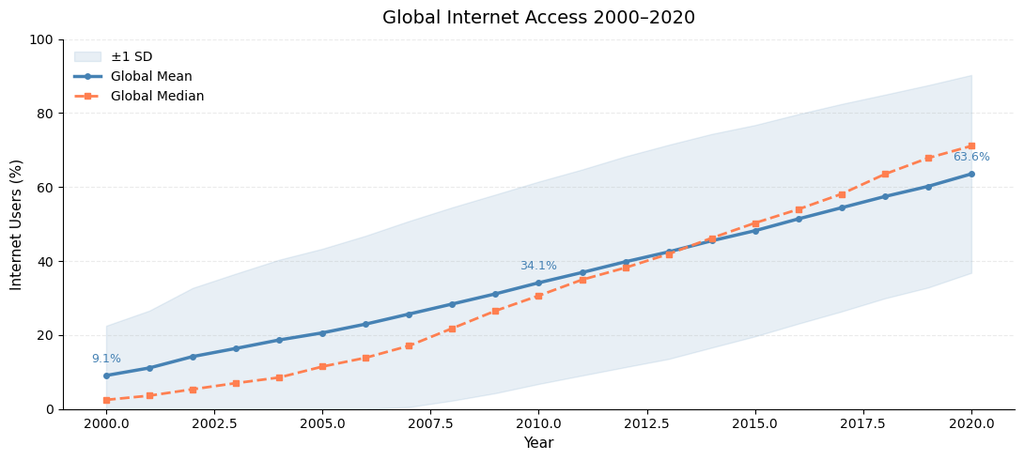

```
Figure 1 saved successfully
```

```python
fig, ax = plt.subplots(figsize=(11, 5))

yearly = df_clean.groupby('year')['internet_users'].agg(['mean', 'median', 'std'])

ax.fill_between(yearly.index,
                (yearly['mean'] - yearly['std']).clip(lower=0),
                (yearly['mean'] + yearly['std']).clip(upper=100),
                alpha=0.12, color='steelblue', label='±1 SD')

ax.plot(yearly.index, yearly['mean'],   color='steelblue', lw=2.5, marker='o',
        markersize=4, label='Global Mean')
ax.plot(yearly.index, yearly['median'], color='coral', lw=2, ls='--',
        marker='s', markersize=4, label='Global Median')

# Mark key years
for yr, label in [(2000, '2000'), (2010, '2010'), (2020, '2020')]:
    val = yearly.loc[yr, 'mean']
    ax.annotate(f'{val:.1f}%', xy=(yr, val),
                xytext=(0, 10), textcoords='offset points',
                ha='center', fontsize=9, color='steelblue')

ax.set_title('Global Internet Access 2000–2020', fontsize=14, pad=12)
ax.set_xlabel('Year', fontsize=11)
ax.set_ylabel('Internet Users (%)', fontsize=11)
ax.set_xlim(1999, 2021)
ax.set_ylim(0, 100)
ax.legend(frameon=False, fontsize=10)
ax.spines[['top', 'right']].set_visible(False)
ax.grid(axis='y', alpha=0.25, ls='--')

plt.tight_layout()
plt.savefig('data/fig1_trend.png', dpi=150, bbox_inches='tight')
plt.show()
print("Figure 1 saved successfully")
```

## 3.2 Digital Divide Across Income Groups

Figure 2 further demonstrates clear differences between income groups. By 2020, internet penetration in high-income countries had reached nearly 87%, compared with approximately 35% in low-income countries. Although internet access increased across all income groups, the gap between high- and low-income countries remained substantial throughout the study period.

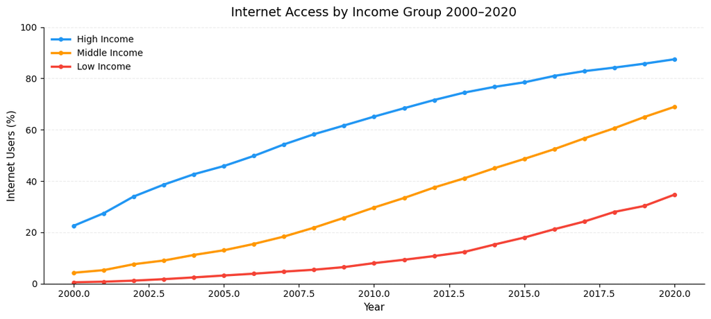

```
Figure 2 saved successfully
```

```python
# Group countries by their 2010 GDP levels into High/Middle/Low income groups (static grouping for comparison)
gdp_2010 = (df_clean[df_clean['year'] == 2010]
            .set_index('country_code')['gdp_per_capita'])

def income_group(gdp):
    if gdp >= 12000: return 'High Income'
    elif gdp >= 3000: return 'Middle Income'
    else: return 'Low Income'

income_map = gdp_2010.apply(income_group).to_dict()
df_clean['income_group'] = df_clean['country_code'].map(income_map)

# Plotting
fig, ax = plt.subplots(figsize=(11, 5))

colors  = {'High Income': '#2196F3', 'Middle Income': '#FF9800', 'Low Income': '#F44336'}
grouped = df_clean.groupby(['year', 'income_group'])['internet_users'].mean().reset_index()

for group, color in colors.items():
    sub = grouped[grouped['income_group'] == group]
    ax.plot(sub['year'], sub['internet_users'],
            color=color, lw=2.5, marker='o', markersize=4, label=group)

ax.set_title('Internet Access by Income Group 2000–2020', fontsize=14, pad=12)
ax.set_xlabel('Year', fontsize=11)
ax.set_ylabel('Internet Users (%)', fontsize=11)
ax.set_xlim(1999, 2021)
ax.set_ylim(0, 100)
ax.legend(frameon=False, fontsize=10)
ax.spines[['top', 'right']].set_visible(False)
ax.grid(axis='y', alpha=0.25, ls='--')

plt.tight_layout()
plt.savefig('data/fig2_income_groups.png', dpi=150, bbox_inches='tight')
plt.show()
print("Figure 2 saved successfully")
```

## 3.3 Distribution Characteristics of Key Variables

Figure 3 presents the distribution of the main variables after data cleaning. GDP per capita displayed strong right-skewness, supporting the use of logarithmic transformation in the regression analysis. The electricity access variable was heavily left-skewed, with most countries clustered near 100% access and a small tail of low-access countries, reflecting a stark infrastructure gap between developed and developing nations.

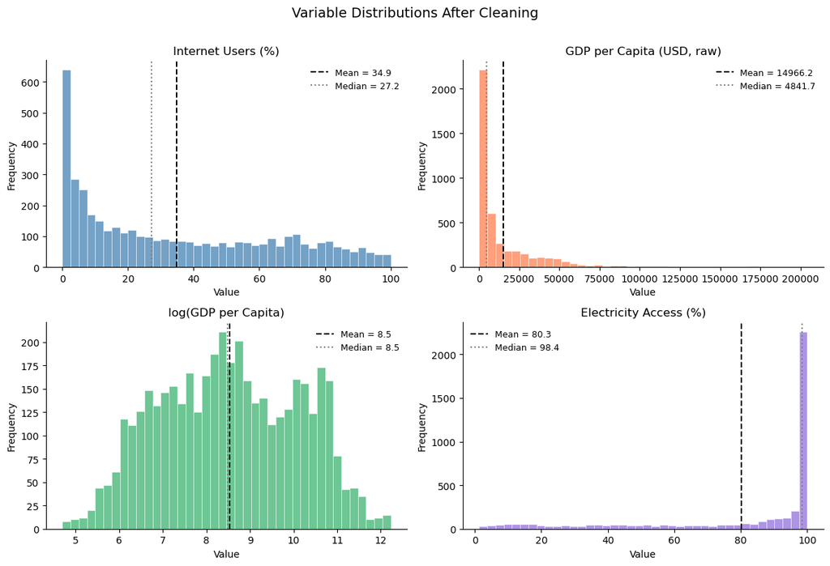

```
Figure 3 saved successfully
```

```python
fig, axes = plt.subplots(2, 2, figsize=(12, 8))

plot_vars = [
    ('internet_users',     'Internet Users (%)',        'steelblue'),
    ('gdp_per_capita',     'GDP per Capita (USD, raw)', 'coral'),
    ('log_gdp',            'log(GDP per Capita)',       'mediumseagreen'),
    ('electricity_access', 'Electricity Access (%)',    'mediumpurple'),
]

for ax, (col, title, color) in zip(axes.flatten(), plot_vars):
    data = df_clean[col].dropna()
    ax.hist(data, bins=40, color=color, alpha=0.75, edgecolor='white', linewidth=0.5)
    ax.axvline(data.mean(),   color='black', lw=1.5, ls='--',
               label=f'Mean = {data.mean():.1f}')
    ax.axvline(data.median(), color='gray',  lw=1.5, ls=':',
               label=f'Median = {data.median():.1f}')
    ax.set_title(title, fontsize=12)
    ax.set_xlabel('Value', fontsize=10)
    ax.set_ylabel('Frequency', fontsize=10)
    ax.legend(fontsize=9, frameon=False)
    ax.spines[['top', 'right']].set_visible(False)

fig.suptitle('Variable Distributions After Cleaning', fontsize=14, y=1.01)
plt.tight_layout()
plt.savefig('data/fig3_distributions.png', dpi=150, bbox_inches='tight')
plt.show()
print("Figure 3 saved successfully")
```

## 3.4 Analysis of Variable Correlations

The Pearson correlation matrix shown in Figure 4 indicates positive relationships between internet penetration and all explanatory variables. Log GDP per capita exhibited the strongest correlation with internet access (r = 0.80), followed by electricity access (r = 0.60) and urban population share (r = 0.58). These results provide preliminary support for the subsequent regression analysis.

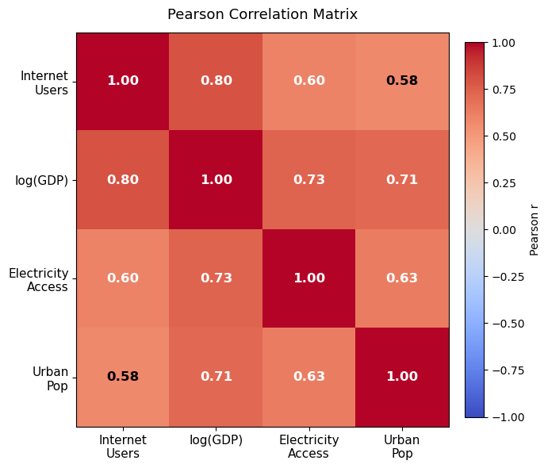

```
Figure 4 saved successfully
```

```python
corr_cols   = ['internet_users', 'log_gdp', 'electricity_access', 'urban_population']
corr_labels = ['Internet\nUsers', 'log(GDP)', 'Electricity\nAccess', 'Urban\nPop']

corr = df_clean[corr_cols].corr()

fig, ax = plt.subplots(figsize=(7, 6))
im = ax.imshow(corr.values, cmap='coolwarm', vmin=-1, vmax=1, aspect='auto')

ax.set_xticks(range(len(corr_cols)))
ax.set_xticklabels(corr_labels, fontsize=11)
ax.set_yticks(range(len(corr_cols)))
ax.set_yticklabels(corr_labels, fontsize=11)

for i in range(len(corr_cols)):
    for j in range(len(corr_cols)):
        val = corr.values[i, j]
        text_color = 'white' if abs(val) > 0.6 else 'black'
        ax.text(j, i, f'{val:.2f}',
                ha='center', va='center',
                fontsize=12, fontweight='bold', color=text_color)

plt.colorbar(im, ax=ax, fraction=0.046, pad=0.04, label='Pearson r')
ax.set_title('Pearson Correlation Matrix', fontsize=13, pad=12)

plt.tight_layout()
plt.savefig('data/fig4_correlation.png', dpi=150, bbox_inches='tight')
plt.show()
print("Figure 4 saved successfully")
```

```python
print("=" * 55)
print("Data cleaning and visualisation complete: an overview of the final dataset")
print("=" * 55)
print(f"Rows: {len(df_clean):,}")
print(f"Countries: {df_clean['country_code'].nunique()}")
print(f"Years: {df_clean['year'].min()} – {df_clean['year'].max()}")
print(f"\nMissing Rates (After Cleaning):")
print(df_clean[['internet_users','gdp_per_capita',
                'electricity_access','urban_population']]
      .isnull().mean().mul(100).round(2).to_string())
print(f"\nIncome Group Distribution (2010):")
print(df_clean[df_clean['year']==2010]['income_group']
      .value_counts().to_string())
print(f"\nSaved Images:")
for i, name in enumerate(['fig1_trend','fig2_income_groups',
                           'fig3_distributions','fig4_correlation'], 1):
    print(f"  Figure {i}: data/{name}.png")
```

```
=======================================================
Data cleaning and visualisation complete: an overview of the final dataset
=======================================================
Rows: 4,305
Countries: 205
Years: 2000 – 2020

Missing Rates (After Cleaning):
internet_users        0.0
gdp_per_capita        0.0
electricity_access    0.0
urban_population      0.0

Income Group Distribution (2010):
income_group
Low Income       69
High Income      68
Middle Income    68

Saved Images:
  Figure 1: data/fig1_trend.png
  Figure 2: data/fig2_income_groups.png
  Figure 3: data/fig3_distributions.png
  Figure 4: data/fig4_correlation.png
```

# 4. Spatial analysis

To further examine the spatial characteristics of disparities in global internet access, this paper employs spatial visualisation and spatial autocorrelation analysis to investigate the geographical distribution, temporal evolution and spatial clustering patterns of internet penetration rates. By constructing a spatial weight matrix, calculating the Moran’s I index and conducting LISA cluster analysis, it is possible to identify the spatial structure of the global digital divide and its evolving trends.

```python
import geopandas as gpd
import libpysal
from libpysal.weights import Queen, KNN
import esda
from esda.moran import Moran, Moran_Local
import splot
from splot.esda import moran_scatterplot, lisa_cluster
import matplotlib.pyplot as plt
import matplotlib.colors as mcolors
import matplotlib.patches as mpatches
import numpy as np
import warnings
warnings.filterwarnings('ignore')
```

```python
import geopandas as gpd
import requests
import os

#Method: Download the shapefile directly from Natural Earth
MAP_PATH = 'data/ne_110m_admin_0_countries.zip'

if not os.path.exists(MAP_PATH):
    print("Downloading world map data...")
    url = "https://naciscdn.org/naturalearth/110m/cultural/ne_110m_admin_0_countries.zip"
    r = requests.get(url, timeout=60)
    with open(MAP_PATH, 'wb') as f:
        f.write(r.content)
    print("✓ Download completed")
else:
    print("✓ Map file already exists, reading directly")

world = gpd.read_file(f"zip://{MAP_PATH}")

print(f"Map column names: {world.columns.tolist()}")
print(f"Number of countries: {len(world)}")
print(f"Example country codes: {world['ADM0_A3'].head().tolist()}")
```

```
✓ Map file already exists, reading directly
Map column names: ['featurecla', 'scalerank', 'LABELRANK', 'SOVEREIGNT', 'SOV_A3', 'ADM0_DIF', 'LEVEL', 'TYPE', 'TLC', 'ADMIN', 'ADM0_A3', 'GEOU_DIF', 'GEOUNIT', 'GU_A3', 'SU_DIF', 'SUBUNIT', 'SU_A3', 'BRK_DIFF', 'NAME', 'NAME_LONG', 'BRK_A3', 'BRK_NAME', 'BRK_GROUP', 'ABBREV', 'POSTAL', 'FORMAL_EN'…
Number of countries: 177
Example country codes: ['FJI', 'TZA', 'SAH', 'CAN', 'USA']
```

```python
def get_year_data(year):
    """Filter cross-sectional data for a specific year from df_clean"""
    return df_clean[df_clean['year'] == year].copy()
df_2020 = get_year_data(2020)
df_2010 = get_year_data(2010)
df_2000 = get_year_data(2000)

world_map = world.merge(
    df_2020[['country_code', 'internet_users', 'log_gdp',
             'electricity_access', 'urban_population']],
    left_on='ADM0_A3', right_on='country_code',
    how='left'
)

matched = world_map['internet_users'].notna().sum()
print(f"Map merging completed: {matched}/{len(world_map)} countries matched successfully")

unmatched = world_map[world_map['internet_users'].isna()]['NAME'].tolist()
print(f"Unmatched (total {len(unmatched)}): {unmatched[:8]} ...")
```

```
Map merging completed: 165/177 countries matched successfully
Unmatched (total 12): ['W. Sahara', 'Sudan', 'Falkland Is.', 'Fr. S. Antarctic Lands', 'Palestine', 'North Korea', 'Taiwan', 'Antarctica'] ...
```

## 4.1 Spatial Patterns of Internet Access

This colour-coded map (Figure 5) shows that internet access in 2020 exhibited a distinct pattern of spatial clustering. Countries with high internet penetration rates were mainly concentrated in North America, Western Europe and Oceania, whilst regions with persistently low levels of internet access formed a continuous band stretching across sub-Saharan Africa and parts of South Asia. This non-random geographical distribution pattern provides intuitive evidence of spatial autocorrelation, which prompted us to conduct formal statistical tests in the following section.

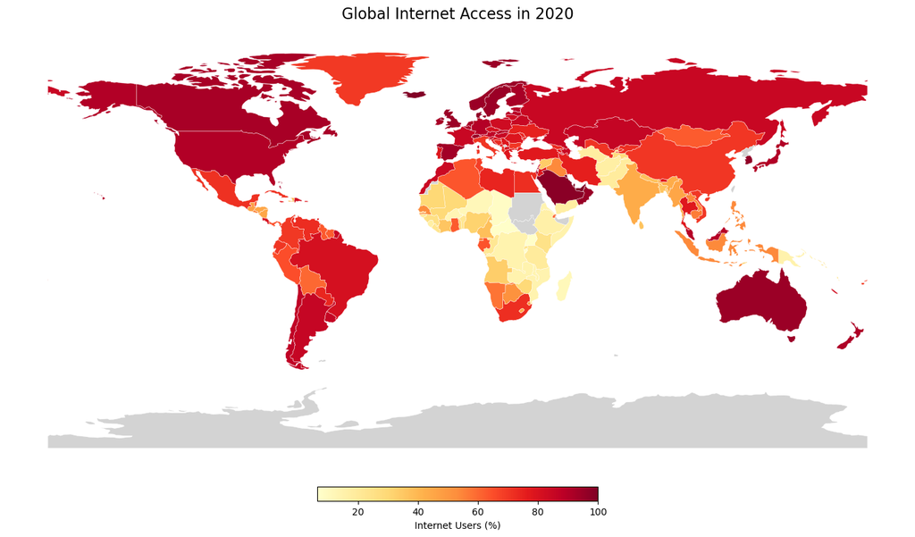

```
Figure 5 saved successfully
```

```python
fig, ax = plt.subplots(1, 1, figsize=(16, 8))

world_map.plot(
    column='internet_users',
    ax=ax,
    cmap='YlOrRd',
    legend=True,
    legend_kwds={
        'label': 'Internet Users (%)',
        'orientation': 'horizontal',
        'fraction': 0.03,
        'pad': 0.04,
        'shrink': 0.6
    },
    missing_kwds={'color': 'lightgrey', 'label': 'No Data'},
    edgecolor='white',
    linewidth=0.3
)

ax.set_title('Global Internet Access in 2020', fontsize=16, pad=15)
ax.set_axis_off()

plt.tight_layout()
plt.savefig('data/fig5_world_map_2020.png', dpi=150, bbox_inches='tight')
plt.show()
print("Figure 5 saved successfully")
```

## 4.2 The Temporal Evolution of Spatial Inequality

A time-series comparison of internet access maps for 2000, 2010 and 2020 (Figure 6) reveals that spatial concentration intensified sharply during the first decade before moderating slightly in the second. Although internet penetration rates have risen significantly across all regions globally, countries with high penetration rates—primarily concentrated in North America, Europe and East Asia—have gradually coalesced into increasingly distinct spatial clusters, whilst penetration rates in sub-Saharan Africa have remained persistently low. Global Moran's I rose from 0.449 in 2000 to 0.694 in 2010, then eased to 0.616 by 2020, suggesting that spatial diffusion may have begun to reach previously peripheral regions in the second decade. Nevertheless, the overall level of spatial clustering remains high throughout the study period, indicating that spatial inequality in internet access is a structurally entrenched characteristic rather than a transient feature of the early diffusion phase.

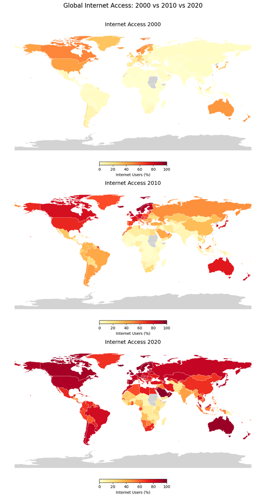

```
Figure 6 saved successfully
```

```python
YEARS = [2000, 2010, 2020]
fig, axes = plt.subplots(3, 1, figsize=(16, 18))

year_dfs = {2000: df_2000, 2010: df_2010, 2020: df_2020}

for ax, year in zip(axes, YEARS):
    df_yr = year_dfs[year]
    wmap = world.merge(df_yr[['country_code', 'internet_users']],
                       left_on='ADM0_A3', right_on='country_code', how='left')
    wmap.plot(
        column='internet_users',
        ax=ax,
        cmap='YlOrRd',
        vmin=0, vmax=100,          # Fixed colour scales facilitate comparison of the three images
        legend=True,
        legend_kwds={
            'label': 'Internet Users (%)',
            'orientation': 'horizontal',
            'fraction': 0.025,
            'pad': 0.04,
            'shrink': 0.5
        },
        missing_kwds={'color': 'lightgrey'},
        edgecolor='white',
        linewidth=0.3
    )
    ax.set_title(f'Internet Access {year}', fontsize=14, pad=10)
    ax.set_axis_off()

plt.suptitle('Global Internet Access: 2000 vs 2010 vs 2020',
             fontsize=16, y=1.01)
plt.tight_layout()
plt.savefig('data/fig6_world_maps_3years.png', dpi=150, bbox_inches='tight')
plt.show()
print("Figure 6 saved successfully")
```

## 4.3 Construction of the spatial weight matrix

A spatial weight matrix was constructed for 165 countries. First, a Queen’s adjacency matrix was specified; the results showed that each country had an average of 3.47 neighbouring countries. However, under this configuration, 19 island nations were identified as isolated nodes with no adjacent neighbours. To address this limitation and ensure connectivity among all observations, a K-nearest neighbours matrix (KNN-5) was additionally constructed, and alternative settings of K=4 and K=6 were subsequently employed in robustness tests.

```python
gdf_2020 = world_map.dropna(subset=['internet_users']).reset_index(drop=True)
print(f"Number of countries used for spatial analysis：{len(gdf_2020)}")

w_queen = Queen.from_dataframe(gdf_2020, silence_warnings=True)
w_knn5  = KNN.from_dataframe(gdf_2020, k=5)

w_queen.transform = 'R'
w_knn5.transform  = 'R'

print(f"Queen matrix: average number of neighbors = {w_queen.mean_neighbors:.2f}")
print(f"KNN-5 matrix: average number of neighbors = {w_knn5.mean_neighbors:.2f}")
print(f"Queen isolated nodes: {len(w_queen.islands)}")
```

```
Number of countries used for spatial analysis：165
Queen matrix: average number of neighbors = 3.47
KNN-5 matrix: average number of neighbors = 5.00
Queen isolated nodes: 19
```

## 4.4 Spatial autocorrelation test

The results of the global Moran's I statistics confirm that there is significant positive spatial autocorrelation in internet access at all three time points. The index rose from 0.449 in 2000 to 0.694 in 2010, before falling slightly to 0.616 in 2020; all values are statistically significant at the p < 0.01 level. These results indicate that countries with similar internet penetration rates exhibit systematic spatial clustering, providing initial motivation for spatial econometric modelling. As shown in Section 5.1, however, OLS residuals no longer exhibit significant spatial autocorrelation after controlling for GDP, electricity access and urbanisation, suggesting that the observed clustering is largely mediated by the geographic concentration of these explanatory variables rather than independent spatial diffusion processes. Spatial models are therefore estimated as robustness checks rather than as a correction for violated OLS assumptions.

```python
print("=" * 55)
print("Global Moran's I Results (KNN-5 Weight Matrix)")
print("=" * 55)
print(f"{'Year':>6}  {'Moran I':>10}  {'E[I]':>8}  {'p-value':>10}  {'Conclusion':>12}")
print("-" * 55)

moran_results = {}
year_dfs = {2000: df_2000, 2010: df_2010, 2020: df_2020}

for year in YEARS:
    df_yr = year_dfs[year]
    gdf_yr = world.merge(
        df_yr[['country_code', 'internet_users']],
        left_on='ADM0_A3', right_on='country_code', how='left'
    )
    gdf_yr = gdf_yr.dropna(subset=['internet_users']).reset_index(drop=True)

    w_yr = KNN.from_dataframe(gdf_yr, k=5)
    w_yr.transform = 'R'

    y  = gdf_yr['internet_users'].values
    mi = Moran(y, w_yr, permutations=999)

    moran_results[year] = {'I': mi.I, 'EI': mi.EI, 'p': mi.p_sim, 'obj': mi}

    sig = "Significant Positive Correlation" if mi.p_sim < 0.05 and mi.I > 0 else "Not Significant"
    print(f"{year:>6}  {mi.I:>10.4f}  {mi.EI:>8.4f}  {mi.p_sim:>10.4f}  {sig:>12}")

print("=" * 55)
```

```
=======================================================
Global Moran's I Results (KNN-5 Weight Matrix)
=======================================================
  Year     Moran I      E[I]     p-value    Conclusion
-------------------------------------------------------
  2000      0.4493   -0.0061      0.0010  Significant Positive Correlation
  2010      0.6939   -0.0061      0.0010  Significant Positive Correlation
  2020      0.6157   -0.0061      0.0010  Significant Positive Correlation
=======================================================
```

The Moran’s I plot (Figure 7) provides a visual confirmation of the spatial autocorrelation findings. In all three periods, the observations are predominantly clustered along the positive diagonal, suggesting that countries with above-average internet access levels tend to be surrounded by neighbouring countries with similarly high access levels (high-high), whilst countries with lower access levels systematically cluster with other countries of similar access levels (low-low). The steepening of the regression slope between 2000 and 2010 reflects an intensification of spatial polarisation, whilst the slight easing of this trend by 2020 may indicate that spatial diffusion has begun to spread to regions that were previously on the periphery.

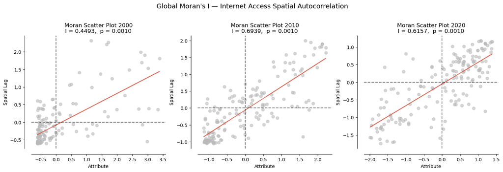

```
Figure 7 saved successfully
```

```python
fig, axes = plt.subplots(1, 3, figsize=(15, 5))

for ax, year in zip(axes, YEARS):
    mi = moran_results[year]['obj']
    moran_scatterplot(mi, ax=ax, aspect_equal=False)
    ax.set_title(f"Moran Scatter Plot {year}\n"
                 f"I = {mi.I:.4f},  p = {mi.p_sim:.4f}",
                 fontsize=12)
    ax.spines[['top', 'right']].set_visible(False)

fig.suptitle("Global Moran's I — Internet Access Spatial Autocorrelation",
             fontsize=14, y=1.02)
plt.tight_layout()
plt.savefig('data/fig7_moranI_scatter.png', dpi=150, bbox_inches='tight')
plt.show()
print("Figure 7 saved successfully")
```

```python
# Calculate the local Moran’s I for 2020
y_2020 = gdf_2020['internet_users'].values
lisa = Moran_Local(y_2020, w_knn5, permutations=999, seed=42)

# Write the LISA results back to the GeoDataFrame
gdf_2020 = gdf_2020.copy()
gdf_2020['lisa_Is']    = lisa.Is           # Local I values
gdf_2020['lisa_q']     = lisa.q            # Quadrant (1=HH,2=LH,3=LL,4=HL)
gdf_2020['lisa_p']     = lisa.p_sim        # Significance
gdf_2020['lisa_sig']   = lisa.p_sim < 0.05 # Is significant

# Quadrant labels (only annotate significant regions)
quad_labels = {1: 'High-High', 2: 'Low-High', 3: 'Low-Low', 4: 'High-Low'}
gdf_2020['cluster_type'] = 'Not Significant'
mask = gdf_2020['lisa_sig']
gdf_2020.loc[mask, 'cluster_type'] = gdf_2020.loc[mask, 'lisa_q'].map(quad_labels)

# Count occurrences of each type
print("LISA cluster statistics (2020, p < 0.05):")
print(gdf_2020['cluster_type'].value_counts().to_string())
```

```
LISA cluster statistics (2020, p < 0.05):
cluster_type
Not Significant    94
Low-Low            35
High-High          31
High-Low            4
Low-High            1
```

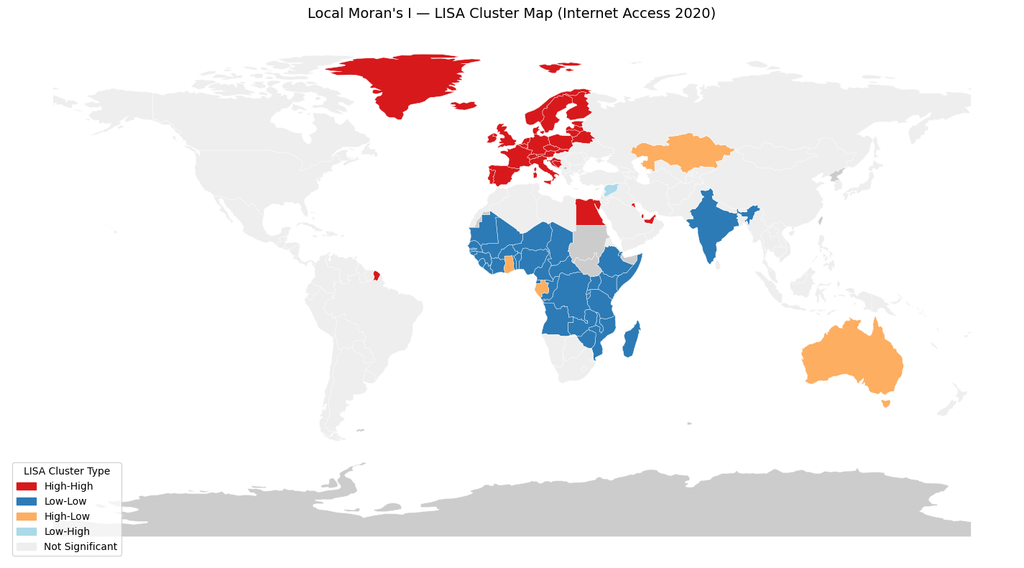

```
Figure 8 saved successfully
```

```python
color_map = {
    'High-High'       : '#d7191c',
    'Low-Low'         : '#2c7bb6',
    'High-Low'        : '#fdae61',
    'Low-High'        : '#abd9e9',
    'Not Significant' : '#eeeeee',
}

fig, ax = plt.subplots(figsize=(16, 8))

for cluster_type, color in color_map.items():
    subset = gdf_2020[gdf_2020['cluster_type'] == cluster_type]
    if len(subset) > 0:
        subset.plot(ax=ax, color=color, edgecolor='white',
                    linewidth=0.3, label=cluster_type)

# Countries not matched are highlighted in grey
world[~world['ADM0_A3'].isin(gdf_2020['ADM0_A3'])].plot(
    ax=ax, color='#cccccc', edgecolor='white', linewidth=0.3)

patches = [mpatches.Patch(color=c, label=l) for l, c in color_map.items()]
ax.legend(handles=patches, loc='lower left', fontsize=10,
          frameon=True, title='LISA Cluster Type')

ax.set_title("Local Moran's I — LISA Cluster Map (Internet Access 2020)",
             fontsize=14, pad=12)
ax.set_axis_off()

plt.tight_layout()
plt.savefig('data/fig8_lisa_cluster.png', dpi=150, bbox_inches='tight')
plt.show()
print("Figure 8 saved successfully")
```

```python
print("=" * 60)
print("Key findings of the spatial analysis")
print("=" * 60)

for year in YEARS:
    r = moran_results[year]
    print(f"\nYear {year}: Global Moran's I = {r['I']:.4f} (p-value = {r['p']:.4f})")

hh = (gdf_2020['cluster_type'] == 'High-High').sum()
ll = (gdf_2020['cluster_type'] == 'Low-Low').sum()
hl = (gdf_2020['cluster_type'] == 'High-Low').sum()
lh = (gdf_2020['cluster_type'] == 'Low-High').sum()
ns = (gdf_2020['cluster_type'] == 'Not Significant').sum()

print(f"""
LISA cluster results (2020):
  High-High (High-High clustering): {hh} countries
  Low-Low   (Low-Low clustering): {ll} countries
  High-Low  (Spatial heterogeneity): {hl} countries
  Low-High  (Spatial heterogeneity): {lh} countries
  Not Significant      ：{ns} countries
""")
```

```
============================================================
Key findings of the spatial analysis
============================================================

Year 2000: Global Moran's I = 0.4493 (p-value = 0.0010)

Year 2010: Global Moran's I = 0.6939 (p-value = 0.0010)

Year 2020: Global Moran's I = 0.6157 (p-value = 0.0010)

LISA cluster results (2020):
  High-High (High-High clustering): 31 countries
  Low-Low   (Low-Low clustering): 35 countries
  High-Low  (Spatial heterogeneity): 4 countries
  Low-High  (Spatial heterogeneity): 1 countries
  Not Significant      ：94 countries
```

# 5. Spatial Modelling and Robustness Analysis

To further examine the spatial mechanisms underlying internet access inequality, this paper builds upon ordinary least squares (OLS) regression to construct spatial lag models (SLM), spatial error models (SEM) and spatial Durbin models (SDM), and conducts robustness analyses using different spatial weight matrices. By comparing spatial coefficients, model fit statistics and parameter stability across different model specifications, we can identify the specific sources of spatial dependence and verify the robustness of the core research findings.

```python
import numpy as np
import pandas as pd
import matplotlib.pyplot as plt
import matplotlib.gridspec as gridspec
import statsmodels.api as sm
from scipy import stats
import spreg
from spreg import OLS, ML_Lag, ML_Error
from esda.moran import Moran
import warnings
warnings.filterwarnings('ignore')
```

```python
# The country_code was added during the merge; the country name is specified using NAME
reg_df = gdf_2020[['country_code', 'NAME',
                    'internet_users', 'log_gdp',
                    'electricity_access', 'urban_population']].dropna().copy()

reg_df = reg_df.rename(columns={'NAME': 'country_name'})
reg_df = reg_df.reset_index(drop=True)

print(f"Regression sample size: {len(reg_df)} countries")
print(f"Column names: {reg_df.columns.tolist()}")
print()
print(reg_df[['internet_users','log_gdp',
              'electricity_access','urban_population']].describe().round(2))
```

```
Regression sample size: 165 countries
Column names: ['country_code', 'country_name', 'internet_users', 'log_gdp', 'electricity_access', 'urban_population']

       internet_users  log_gdp  electricity_access  urban_population
count          165.00   165.00              165.00            165.00
mean            61.57     8.60               84.26             60.54
std             27.80     1.44               25.61             21.38
min              6.43     5.54                9.10             14.17
25%             36.11     7.56               71.50             43.21
50%             70.70     8.56               99.90             63.08
75%             84.71     9.73              100.00             77.64
max            100.00    11.67              100.00            100.00
```

```python
from libpysal.weights import KNN

# reg_df.index corresponds to the rows in gdf_2020 after `dropna` has been applied; these need to be realigned.
# Retrieve the same rows from gdf_2020 (matching by country_code).
gdf_reg = gdf_2020[gdf_2020['country_code'].isin(reg_df['country_code'])].copy()
gdf_reg = gdf_reg.reset_index(drop=True)

# Ensure that the order matches that of `reg_df`
reg_df = reg_df.set_index('country_code')
reg_df = reg_df.loc[gdf_reg['country_code']].reset_index()

assert len(gdf_reg) == len(reg_df), "Row counts do not match"
print(f"Alignment completed, sample size: {len(gdf_reg)}")

w_reg = KNN.from_dataframe(gdf_reg, k=5)
w_reg.transform = 'R'

print(f"KNN-5 weights matrix built, average neighbors: {w_reg.mean_neighbors:.1f}")

# numpy arrays
y      = reg_df['internet_users'].values.reshape(-1, 1)
X_cols = ['log_gdp', 'electricity_access', 'urban_population']
X      = reg_df[X_cols].values

print(f"y shape: {y.shape},  X shape: {X.shape}")
```

```
Alignment completed, sample size: 165
KNN-5 weights matrix built, average neighbors: 5.0
y shape: (165, 1),  X shape: (165, 3)
```

## 5.1 OLS model

OLS residual diagnostics indicate no statistically significant spatial dependence after controlling for log GDP per capita, electricity access and urban population share (Moran's I = 0.052, p = 0.125; LM-Lag p = 0.244; LM-Error p = 0.263). This suggests that the explanatory variables capture much of the spatial variation in internet penetration across countries. However, the assumptions of normality (Jarque-Bera p < 0.001) and homoscedasticity (Breusch-Pagan p < 0.001) remain violated. Spatial econometric models are therefore estimated as robustness checks and for comparison with the baseline OLS specification.

```python
# OLS baseline model
ols = OLS(
    y, X,
    w=w_reg,
    name_y='internet_users',
    name_x=X_cols,
    name_ds='World 2020',
    spat_diag=True,      # Automatically calculate spatial diagnostic statistics
    moran=True
)

print(ols.summary)
```

```
REGRESSION RESULTS
------------------

SUMMARY OF OUTPUT: ORDINARY LEAST SQUARES
-----------------------------------------
Data set            :  World 2020
Weights matrix      :     unknown
Dependent Variable  :internet_users                Number of Observations:         165
Mean dependent var  :     61.5697                Number of Variables   :           4
S.D. dependent var  :     27.8021                Degrees of Freedom    :         161
R-squared           :      0.8684
Adjusted R-squared  :      0.8660
Sum squared residual:     16678.3                F-statistic           :    354.2307
Sigma-square        :     103.592                Prob(F-statistic)     :   1.172e-70
S.E. of regression  :      10.178                Log likelihood        :    -614.938
Sigma-square ML     :     101.081                Akaike info criterion :    1237.876
S.E of regression ML:     10.0539                Schwarz criterion     :    1250.300

------------------------------------------------------------------------------------
            Variable     Coefficient       Std.Error     t-Statistic     Probability
------------------------------------------------------------------------------------
            CONSTANT       -66.44861         5.18021       -12.82739         0.00000
             log_gdp         9.14948         0.92276         9.91532         0.00000
  electricity_access         0.37724         0.04367         8.63936         0.00000
    urban_population         0.28927         0.05521         5.23962         0.00000
------------------------------------------------------------------------------------

REGRESSION DIAGNOSTICS
MULTICOLLINEARITY CONDITION NUMBER          23.811

TEST ON NORMALITY OF ERRORS
TEST                             DF        VALUE           PROB
Jarque-Bera                       2         38.997           0.0000

DIAGNOSTICS FOR HETEROSKEDASTICITY
RANDOM COEFFICIENTS
TEST                             DF        VALUE           PROB
Breusch-Pagan test                3         29.343           0.0000
Koenker-Bassett test              3         14.759           0.0020

DIAGNOSTICS FOR SPATIAL DEPENDENCE
- SARERR -
TEST                           MI/DF       VALUE           PROB
Moran's I (error)              0.0516        1.533           0.1253
Lagrange Multiplier (lag)         1          1.356           0.2442
Robust LM (lag)                   1          0.558           0.4552
Lagrange Multiplier (error)       1          1.255           0.2627
Robust LM (error)                 1          0.456           0.4996
Lagrange Multiplier (SARMA)       2          1.812           0.4041

- Spatial Durbin -
TEST                              DF       VALUE           PROB
LM test for WX                    3          0.827           0.8429
Robust LM WX test                 3          0.726           0.8672
Lagrange Multiplier (lag)         1          1.356           0.2442
Robust LM Lag - SDM               1          1.255           0.2627
Joint test for SDM                4          2.082           0.7207
================================ END OF REPORT =====================================
```

```python
# Extract coefficients, standard errors, t-values, and p-values
coef_names = ['Intercept'] + X_cols
betas      = ols.betas.flatten()
std_errs   = np.sqrt(np.diag(ols.vm))
t_stats    = betas / std_errs
p_vals     = 2 * (1 - stats.t.cdf(np.abs(t_stats), df=ols.n - ols.k))

ols_table = pd.DataFrame({
    'Coefficient' : betas.round(4),
    'Std Error'   : std_errs.round(4),
    't-stat'      : t_stats.round(3),
    'p-value'     : p_vals.round(4),
    'Significant' : ['***' if p < 0.01 else '**' if p < 0.05
                      else '*' if p < 0.1 else '' for p in p_vals]
}, index=coef_names)

print("=" * 60)
print("OLS Regression Results (Dependent Variable: Internet Access %)")
print("=" * 60)
print(ols_table.to_string())
print(f"\nR²       = {ols.r2:.4f}")
print(f"Adj R²   = {ols.ar2:.4f}")
print(f"AIC      = {ols.aic:.4f}")
print(f"Log-Lik  = {ols.logll:.4f}")
print(f"N        = {ols.n}")
```

```
============================================================
OLS Regression Results (Dependent Variable: Internet Access %)
============================================================
                    Coefficient  Std Error  t-stat  p-value Significant
Intercept              -66.4486     5.1802 -12.827      0.0         ***
log_gdp                  9.1495     0.9228   9.915      0.0         ***
electricity_access       0.3772     0.0437   8.639      0.0         ***
urban_population         0.2893     0.0552   5.240      0.0         ***

R²       = 0.8684
Adj R²   = 0.8660
AIC      = 1237.8764
Log-Lik  = -614.9382
N        = 165
```

```python
# Extracting residuals from the OLS object

# Conducting Moran's I test on the residuals
mi_resid = Moran(residuals, w_reg, permutations=999)

print("=" * 55)
print("OLS Residuals Spatial Autocorrelation Test (Moran's I)")
print("=" * 55)
print(f"Moran's I  = {mi_resid.I:.4f}")
print(f"Expected Value E[I] = {mi_resid.EI:.4f}")
print(f"z-score    = {mi_resid.z_norm:.4f}")
print(f"p-value    = {mi_resid.p_sim:.4f}")
print()

if mi_resid.p_sim < 0.05:
    print(" Conclusion: OLS residuals exhibit significant spatial autocorrelation (p < 0.05)")
    print("   OLS model is not suitable, spatial econometric models must be introduced")
else:
    print(" Conclusion: OLS residuals do not exhibit significant spatial autocorrelation")

# Reading the built-in Lagrange Multiplier test in spreg at the same time
print()
print("Lagrange Multiplier Test (Built-in to spreg):")
print(f"  LM-Lag   Statistic={ols.lm_lag[0]:.4f},  p={ols.lm_lag[1]:.4f}")
print(f"  LM-Error Statistic={ols.lm_error[0]:.4f},  p={ols.lm_error[1]:.4f}")
print(f"  RLM-Lag  Statistic={ols.rlm_lag[0]:.4f},  p={ols.rlm_lag[1]:.4f}")
print(f"  RLM-ErrorStatistic={ols.rlm_error[0]:.4f},  p={ols.rlm_error[1]:.4f}")
print()
```

```
=======================================================
OLS Residuals Spatial Autocorrelation Test (Moran's I)
=======================================================
Moran's I  = 0.0516
Expected Value E[I] = -0.0061
z-score    = 1.2766
p-value    = 0.1080

✓ Conclusion: OLS residuals do not exhibit significant spatial autocorrelation

Lagrange Multiplier Test (Built-in to spreg):
  LM-Lag   Statistic=1.3564,  p=0.2442
  LM-Error Statistic=1.2546,  p=0.2627
  RLM-Lag  Statistic=0.5576,  p=0.4552
  RLM-ErrorStatistic=0.4558,  p=0.4996
```

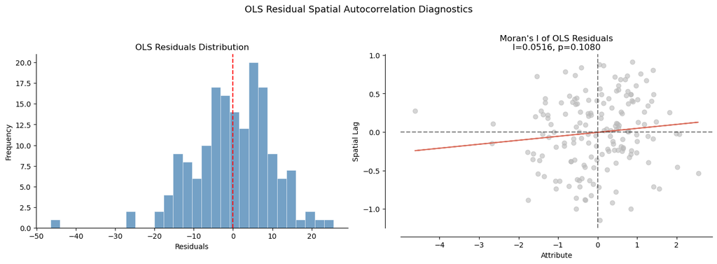

```
Figure 9 saved successfully
```

```python
fig, axes = plt.subplots(1, 2, figsize=(14, 5))

# Left plot: Histogram of residuals
ax1 = axes[0]
ax1.hist(residuals, bins=30, color='steelblue', alpha=0.75,
         edgecolor='white', linewidth=0.5)
ax1.axvline(0, color='red', lw=1.5, ls='--')
ax1.set_title('OLS Residuals Distribution', fontsize=12)
ax1.set_xlabel('Residuals')
ax1.set_ylabel('Frequency')
ax1.spines[['top','right']].set_visible(False)

# Right plot: Moran scatter plot (residuals)
ax2 = axes[1]
from splot.esda import moran_scatterplot
moran_scatterplot(mi_resid, ax=ax2, aspect_equal=False)
ax2.set_title(f"Moran's I of OLS Residuals\nI={mi_resid.I:.4f}, p={mi_resid.p_sim:.4f}",
              fontsize=12)
ax2.spines[['top','right']].set_visible(False)

plt.suptitle('OLS Residual Spatial Autocorrelation Diagnostics',
             fontsize=13, y=1.02)
plt.tight_layout()
plt.savefig('data/fig9_ols_residuals.png', dpi=150, bbox_inches='tight')
plt.show()
print("Figure 9 saved successfully")
```

Although the OLS model captures a substantial proportion of the variation in internet penetration, spatial econometric models are further estimated to examine whether any remaining spatial processes influence the results. Spatial regression models also provide a useful robustness check by allowing spatial interactions and spillover effects to be incorporated directly into the model specification.

The following sections therefore introduce the Spatial Lag Model (SLM), Spatial Error Model (SEM) and Spatial Durbin Model (SDM) to compare their performance with the baseline OLS model and to further assess the spatial structure of global internet inequality.

## 5.2 SLM model

The spatial autoregressive coefficient is ρ = 0.065 (p = 0.252), which is not statistically significant, indicating no meaningful direct internet spillover from neighbouring countries after controlling for economic and infrastructure factors. Model fit does not improve over OLS (AIC: 1238.6 vs 1237.9). The impact decomposition reveals a modest indirect GDP per capita effect (indirect effect = 0.610), suggesting a weak cross-border channel through the spatial multiplier.

```python
# Spatial Lag Model (SLM)
slm = ML_Lag(
    y, X,
    w=w_reg,
    name_y='internet_users',
    name_x=X_cols,
    name_ds='World 2020'
)

print(slm.summary)
```

```
REGRESSION RESULTS
------------------

SUMMARY OF OUTPUT: MAXIMUM LIKELIHOOD SPATIAL LAG (METHOD = FULL)
-----------------------------------------------------------------
Data set            :  World 2020
Weights matrix      :     unknown
Dependent Variable  :internet_users                Number of Observations:         165
Mean dependent var  :     61.5697                Number of Variables   :           5
S.D. dependent var  :     27.8021                Degrees of Freedom    :         160
Pseudo R-squared    :      0.8696
Spatial Pseudo R-squared:  0.8688
Log likelihood      :   -614.2804
Sigma-square ML     :    100.2123                Akaike info criterion :    1238.561
S.E of regression   :     10.0106                Schwarz criterion     :    1254.091

------------------------------------------------------------------------------------
            Variable     Coefficient       Std.Error     z-Statistic     Probability
------------------------------------------------------------------------------------
            CONSTANT       -64.51359         5.35601       -12.04507         0.00000
             log_gdp         8.73064         0.97832         8.92407         0.00000
  electricity_access         0.35273         0.04739         7.44315         0.00000
    urban_population         0.28605         0.05446         5.25213         0.00000
    W_internet_users         0.06533         0.05704         1.14531         0.25208
------------------------------------------------------------------------------------

SPATIAL LAG MODEL IMPACTS
Impacts computed using the 'simple' method.
            Variable         Direct        Indirect          Total
             log_gdp         8.7306          0.6103          9.3409
  electricity_access         0.3527          0.0247          0.3774
    urban_population         0.2861          0.0200          0.3060
================================ END OF REPORT =====================================
```

## 5.3 SEM model

The spatial error coefficient is λ = 0.141 (p = 0.246), which is not significant, suggesting that spatially correlated omitted variables do not substantially bias OLS estimates. Nevertheless, SEM achieves the lowest AIC among the models estimated (1236.7). Substantive coefficients are virtually identical to OLS—log GDP per capita (9.150 vs 9.149), electricity access (0.372 vs 0.377) and urban population (0.289 vs 0.289)—providing strong evidence that coefficients are robust to spatial model specification.

```python
# Spatial Error Model（SEM）
sem = ML_Error(
    y, X,
    w=w_reg,
    name_y='internet_users',
    name_x=X_cols,
    name_ds='World 2020'
)

print(sem.summary)
```

```
REGRESSION RESULTS
------------------

SUMMARY OF OUTPUT: ML SPATIAL ERROR (METHOD = full)
---------------------------------------------------
Data set            :  World 2020
Weights matrix      :     unknown
Dependent Variable  :internet_users                Number of Observations:         165
Mean dependent var  :     61.5697                Number of Variables   :           4
S.D. dependent var  :     27.8021                Degrees of Freedom    :         161
Pseudo R-squared    :      0.8684
Log likelihood      :   -614.3306
Sigma-square ML     :    100.0253                Akaike info criterion :    1236.661
S.E of regression   :     10.0013                Schwarz criterion     :    1249.085

------------------------------------------------------------------------------------
            Variable     Coefficient       Std.Error     z-Statistic     Probability
------------------------------------------------------------------------------------
            CONSTANT       -66.00873         5.50855       -11.98297         0.00000
             log_gdp         9.15012         0.95540         9.57731         0.00000
  electricity_access         0.37214         0.04659         7.98664         0.00000
    urban_population         0.28912         0.05649         5.11844         0.00000
              lambda         0.14056         0.12116         1.16013         0.24600
------------------------------------------------------------------------------------
================================ END OF REPORT =====================================
```

## 5.4 SDM model

The Spatial Durbin model incorporates spatially lagged independent variables alongside the spatial autoregressive term. None of the spatial lag covariates reach significance (W_log_gdp p = 0.391; W_electricity p = 0.856; W_urban_pop p = 0.910), nor does the spatial lag of the dependent variable (p = 0.256). Despite the highest log-likelihood (−613.934), SDM's AIC (1243.9) and BIC (1268.7) exceed SEM's (1236.7; 1249.1). This suggests that the spatial structure in internet access largely reflects the geographic concentration of GDP and infrastructure rather than independent transnational diffusion.

```python
# Spatial Durbin Model（SDM）
# Implementing SDM using GM_Lag and the slX parameter in spreg
from spreg import ML_Lag

# Manually constructing WX (the mean of the neighbouring countries’ independent variables)
import libpysal
Wmat  = w_reg.full()[0]                    # Convert to a dense weight matrix
WX    = Wmat @ X                            # WX: The mean of X for each neighbouring country

X_sdm = np.hstack([X, WX])

X_sdm_cols = (X_cols +
               [f'W_{c}' for c in X_cols])  # Column names

sdm = ML_Lag(
    y, X_sdm,
    w=w_reg,
    name_y='internet_users',
    name_x=X_sdm_cols,
    name_ds='World 2020'
)

print(sdm.summary)
```

```
REGRESSION RESULTS
------------------

SUMMARY OF OUTPUT: MAXIMUM LIKELIHOOD SPATIAL LAG (METHOD = FULL)
-----------------------------------------------------------------
Data set            :  World 2020
Weights matrix      :     unknown
Dependent Variable  :internet_users                Number of Observations:         165
Mean dependent var  :     61.5697                Number of Variables   :           8
S.D. dependent var  :     27.8021                Degrees of Freedom    :         157
Pseudo R-squared    :      0.8704
Spatial Pseudo R-squared:  0.8691
Log likelihood      :   -613.9343
Sigma-square ML     :     99.5584                Akaike info criterion :    1243.869
S.E of regression   :      9.9779                Schwarz criterion     :    1268.716

------------------------------------------------------------------------------------
            Variable     Coefficient       Std.Error     z-Statistic     Probability
------------------------------------------------------------------------------------
            CONSTANT       -56.80807        10.43271        -5.44519         0.00000
             log_gdp         9.10897         1.10919         8.21230         0.00000
  electricity_access         0.34795         0.06608         5.26580         0.00000
    urban_population         0.27922         0.06105         4.57337         0.00000
           W_log_gdp        -1.61446         1.88297        -0.85740         0.39122
W_electricity_access        -0.01697         0.09335        -0.18179         0.85575
  W_urban_population         0.01105         0.09728         0.11360         0.90955
    W_internet_users         0.13782         0.12128         1.13641         0.25578
------------------------------------------------------------------------------------

SPATIAL LAG MODEL IMPACTS
Impacts computed using the 'simple' method.
            Variable         Direct        Indirect          Total
             log_gdp         9.1090          1.4561         10.5651
  electricity_access         0.3480          0.0556          0.4036
    urban_population         0.2792          0.0446          0.3239
           W_log_gdp        -1.6145         -0.2581         -1.8725
W_electricity_access        -0.0170         -0.0027         -0.0197
  W_urban_population         0.0111          0.0018          0.0128
================================ END OF REPORT =====================================
```

## 5.5 Comparison of Results and Robustness

```python
def get_model_stats(model, name):
    return {
        'Model'   : name,
        'N'       : model.n,
        'Log-Lik' : round(model.logll, 3),
        'AIC'     : round(model.aic,   3),
        'R²'      : round(model.pr2 if hasattr(model, 'pr2') else model.r2, 4),
    }

comparison = pd.DataFrame([
    get_model_stats(ols, 'OLS'),
    get_model_stats(slm, 'SLM (Spatial Lag)'),
    get_model_stats(sem, 'SEM (Spatial Error)'),
    get_model_stats(sdm, 'SDM (Spatial Durbin)'),
])

comparison['ΔAIC vs OLS'] = (comparison['AIC'] - comparison.loc[0,'AIC']).round(3)

print("=" * 70)
print("Model Comparison Summary (Dependent Variable: Internet Access Rate %, Cross-section 2020, N={})".format(ols.n))
print("=" * 70)
print(comparison.to_string(index=False))
print()

best = comparison.loc[comparison['AIC'].idxmin(), 'Model']
print(f" Best model by AIC: {best}")
print("  Lower AIC = Better model fit (while penalizing model complexity)")
print("  Higher Log-Likelihood = Better model fit")
print()
```

```
======================================================================
Model Comparison Summary (Dependent Variable: Internet Access Rate %, Cross-section 2020, N=165)
======================================================================
               Model   N  Log-Lik      AIC     R²  ΔAIC vs OLS
                 OLS 165 -614.938 1237.876 0.8684        0.000
   SLM (Spatial Lag) 165 -614.280 1238.561 0.8696        0.685
 SEM (Spatial Error) 165 -614.331 1236.661 0.8684       -1.215
SDM (Spatial Durbin) 165 -613.934 1243.869 0.8704        5.993

 Best model by AIC: SEM (Spatial Error)
  Lower AIC = Better model fit (while penalizing model complexity)
  Higher Log-Likelihood = Better model fit
```

Figure 10 compares coefficients across all four model specifications. The near-identical bar heights for log GDP per capita, electricity access and urban population confirm that core coefficient estimates are robust across OLS, SLM, SEM and SDM.

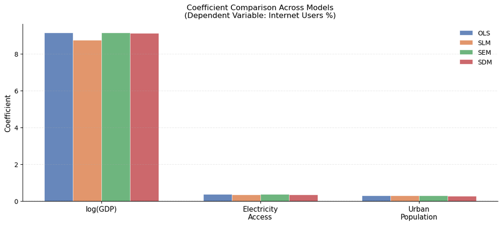

```
Figure 10 saved successfully
```

```python
fig, ax = plt.subplots(figsize=(11, 5))

# Extract the coefficients for the three main independent variables (excluding the intercept and the WX term)
models_info = {
    'OLS' : ols,
    'SLM' : slm,
    'SEM' : sem,
    'SDM' : sdm,
}

var_labels = ['log(GDP)', 'Electricity\nAccess', 'Urban\nPopulation']
x_pos = np.arange(len(X_cols))
width = 0.18
colors_bar = ['#4C72B0','#DD8452','#55A868','#C44E52']

for i, (name, model) in enumerate(models_info.items()):
    # betas[0] = intercept, betas[1:4] = three main independent variables
    coefs = model.betas.flatten()[1:4]
    bars  = ax.bar(x_pos + i * width, coefs, width,
                   label=name, color=colors_bar[i], alpha=0.85,
                   edgecolor='white', linewidth=0.5)

ax.axhline(0, color='black', lw=0.8, ls='--')
ax.set_xticks(x_pos + width * 1.5)
ax.set_xticklabels(var_labels, fontsize=11)
ax.set_ylabel('Coefficient', fontsize=11)
ax.set_title('Coefficient Comparison Across Models\n(Dependent Variable: Internet Users %)',
             fontsize=12, pad=10)
ax.legend(frameon=False, fontsize=10)
ax.spines[['top','right']].set_visible(False)
ax.grid(axis='y', alpha=0.25, ls='--')

plt.tight_layout()
plt.savefig('data/fig10_model_comparison.png', dpi=150, bbox_inches='tight')
plt.show()
print("Figure 10 saved successfully")
```

Robustness tests across KNN-4, KNN-5 and KNN-6 spatial weight matrices show consistently positive spatial autoregressive coefficients (ρ = 0.101, 0.065 and 0.059), confirming directional stability. The monotonically decreasing trend with increasing k indicates that spatial dependence in internet access primarily operates through immediate neighbours and attenuates with distance, consistent with Tobler's First Law of Geography.

```python
#  Verify whether the results are stable with respect to the choice of weight matrix
print("=" * 60)
print("Robustness tests: SLM results under different spatial weighting matrices")
print("=" * 60)
print(f"{'Weight Matrix':<12} {'ρ (Spatial Lag)':>14} {'p(ρ)':>10} {'AIC':>10} {'Log-Lik':>10}")
print("-" * 60)

for k in [4, 5, 6]:
    w_k = KNN.from_dataframe(gdf_reg, k=k)
    w_k.transform = 'R'
    m = ML_Lag(y, X, w=w_k, name_y='internet_users',
               name_x=X_cols, name_ds='World 2020')
    rho   = m.betas[-1][0]
    p_rho = m.z_stat[-1][1]
    print(f"{'KNN-'+str(k):<12} {rho:>14.4f} {p_rho:>10.4f} "
          f"{m.aic:>10.3f} {m.logll:>10.3f}")

print()
```

```
============================================================
Robustness tests: SLM results under different spatial weighting matrices
============================================================
Weight Matrix ρ (Spatial Lag)       p(ρ)        AIC    Log-Lik
------------------------------------------------------------
KNN-4                0.1011     0.0651   1236.611   -613.306
KNN-5                0.0653     0.2521   1238.561   -614.280
KNN-6                0.0585     0.3215   1238.902   -614.451
```

Extending the analysis to both SEM and SLM across all three weight matrices, all six model-matrix combinations yield positive spatial coefficients with consistent distance decay (SEM λ: 0.185→0.141→0.118; SLM ρ: 0.101→0.065→0.059). SEM-KNN4 achieves the lowest AIC (1235.2), further supporting SEM as the preferred specification. The consistently larger spatial coefficients in SEM than SLM suggest that spatially correlated omitted variables—such as regional governance quality or historical infrastructure legacies—play a greater role than direct cross-border internet diffusion.

```python
from spreg import ML_Error, ML_Lag
import numpy as np

print("=" * 70)
print("Robustness tests extension: SEM and SDM under different spatial weighting matrices")
print("=" * 70)

for model_name, ModelClass, extra_kwargs in [
    ('SEM', ML_Error, {}),
    ('SLM', ML_Lag,   {}),
]:
    print(f"\n── {model_name} ──")
    print(f"{'Weight Matrix':<12} {'Spatial Coefficient':>12} {'p-value':>10} {'AIC':>10} {'Log-Lik':>10}")
    print("-" * 56)

    for k in [4, 5, 6]:
        w_k = KNN.from_dataframe(gdf_reg, k=k)
        w_k.transform = 'R'
        m = ModelClass(y, X, w=w_k,
                       name_y='internet_users',
                       name_x=X_cols,
                       **extra_kwargs)
        # The spatial coefficient in SEM is lambda (the last of the betas)
        # The spatial coefficient in SLM is rho
        sp_coef = m.betas[-1][0]
        sp_pval = m.z_stat[-1][1]
        print(f"{'KNN-'+str(k):<12} {sp_coef:>12.4f} {sp_pval:>10.4f} "
              f"{m.aic:>10.3f} {m.logll:>10.3f}")
```

```
======================================================================
Robustness tests extension: SEM and SDM under different spatial weighting matrices
======================================================================

── SEM ──
Weight Matrix Spatial Coefficient    p-value        AIC    Log-Lik
--------------------------------------------------------
KNN-4              0.1852     0.0815   1235.163   -613.581
KNN-5              0.1406     0.2460   1236.661   -614.331
KNN-6              0.1184     0.3776   1237.104   -614.552

── SLM ──
Weight Matrix Spatial Coefficient    p-value        AIC    Log-Lik
--------------------------------------------------------
KNN-4              0.1011     0.0651   1236.611   -613.306
KNN-5              0.0653     0.2521   1238.561   -614.280
KNN-6              0.0585     0.3215   1238.902   -614.451
```

```python
# Using panel data from five time points: 2000, 2005, 2010, 2015 and 2020
# The sample size increased from approximately 160 to approximately 800, resulting in a significant improvement in statistical power

panel_years = [2000, 2005, 2010, 2015, 2020]
df_panel = df_clean[df_clean['year'].isin(panel_years)].copy()

# Include only those countries for which complete data is available for all years
countries_complete = (
    df_panel.groupby('country_code')[['internet_users','log_gdp',
                                       'electricity_access','urban_population']]
    .apply(lambda x: x.notna().all().all())
)
valid_countries = countries_complete[countries_complete].index

df_panel = df_panel[df_panel['country_code'].isin(valid_countries)].copy()
df_panel = df_panel.sort_values(['country_code','year']).reset_index(drop=True)

print(f"✓ Panel data construction completed")
print(f"  Time points: {panel_years}")
print(f"  Number of countries: {df_panel['country_code'].nunique()}")
print(f"  Total rows: {len(df_panel)}")# Using panel data from five time points: 2000, 2005, 2010, 2015 and 2020
# The sample size increased from approximately 160 to approximately 800, resulting in a significant improvement in statistical power

panel_years = [2000, 2005, 2010, 2015, 2020]
df_panel = df_clean[df_clean['year'].isin(panel_years)].copy()

# Include only those countries for which complete data is available for all years
countries_complete = (
    df_panel.groupby('country_code')[['internet_users','log_gdp',
                                       'electricity_access','urban_population']]
    .apply(lambda x: x.notna().all().all())
)
valid_countries = countries_complete[countries_complete].index

df_panel = df_panel[df_panel['country_code'].isin(valid_countries)].copy()
df_panel = df_panel.sort_values(['country_code','year']).reset_index(drop=True)

print(f"✓ Panel data construction completed")
print(f"  Time points: {panel_years}")
print(f"  Number of countries: {df_panel['country_code'].nunique()}")
```

```
✓ Panel data construction completed
  Time points: [2000, 2005, 2010, 2015, 2020]
  Number of countries: 205
  Total rows: 1025
✓ Panel data construction completed
  Time points: [2000, 2005, 2010, 2015, 2020]
  Number of countries: 205
```

```python
import statsmodels.formula.api as smf

# Add year dummy variables to control for time trends
df_panel['year_dummy'] = df_panel['year'].astype(str)

formula = ('internet_users ~ log_gdp + electricity_access '
           '+ urban_population + C(year_dummy)')

panel_ols = smf.ols(formula, data=df_panel).fit(
    cov_type='HC3'   # Heteroscedasticity-robust standard errors
)

print(panel_ols.summary2())
print(f"\nR²     = {panel_ols.rsquared:.4f}")
print(f"Adj R² = {panel_ols.rsquared_adj:.4f}")
print(f"N      = {panel_ols.nobs:.0f}")
```

```
                     Results: Ordinary least squares
=========================================================================
Model:                 OLS                Adj. R-squared:       0.810
Dependent Variable:    internet_users     AIC:                  8261.0843
Date:                  2026-06-01 09:59   BIC:                  8300.5439
No. Observations:      1025               Log-Likelihood:       -4122.5
Df Model:              7                  F-statistic:          709.7
Df Residuals:          1017               Prob (F-statistic):   0.00
R-squared:             0.811              Scale:                183.82
-------------------------------------------------------------------------
                       Coef.   Std.Err.    z     P>|z|   [0.025   0.975]
-------------------------------------------------------------------------
Intercept             -90.3251   2.6310 -34.3307 0.0000 -95.4818 -85.1684
C(year_dummy)[T.2005]   6.3246   1.3756   4.5976 0.0000   3.6284   9.0208
C(year_dummy)[T.2010]  14.7579   1.3804  10.6908 0.0000  12.0523  17.4634
C(year_dummy)[T.2015]  27.6711   1.4111  19.6099 0.0000  24.9055  30.4368
C(year_dummy)[T.2020]  42.3927   1.4390  29.4602 0.0000  39.5723  45.2130
log_gdp                11.8210   0.4344  27.2127 0.0000  10.9696  12.6724
electricity_access      0.0313   0.0220   1.4209 0.1553  -0.0119   0.0745
urban_population        0.0784   0.0255   3.0686 0.0022   0.0283   0.1284
-------------------------------------------------------------------------
Omnibus:                 8.141           Durbin-Watson:             1.011
Prob(Omnibus):           0.017           Jarque-Bera (JB):          5.843
Skew:                    -0.039          Prob(JB):                  0.054
Kurtosis:                2.638           Condition No.:             647
=========================================================================
Notes:
[1] Standard Errors are heteroscedasticity robust (HC3)

R²     = 0.8113
Adj R² = 0.8100
N      = 1025
```

Figure 11 summarises the four key empirical findings: a strong positive correlation between log GDP per capita and internet penetration ; SEM as the best-fitting model by AIC (top right); persistent and significant spatial autocorrelation at all three time points (all p < 0.001, bottom left); and spatial coefficients that remain positive and decrease monotonically with k in both SEM and SLM (bottom right).

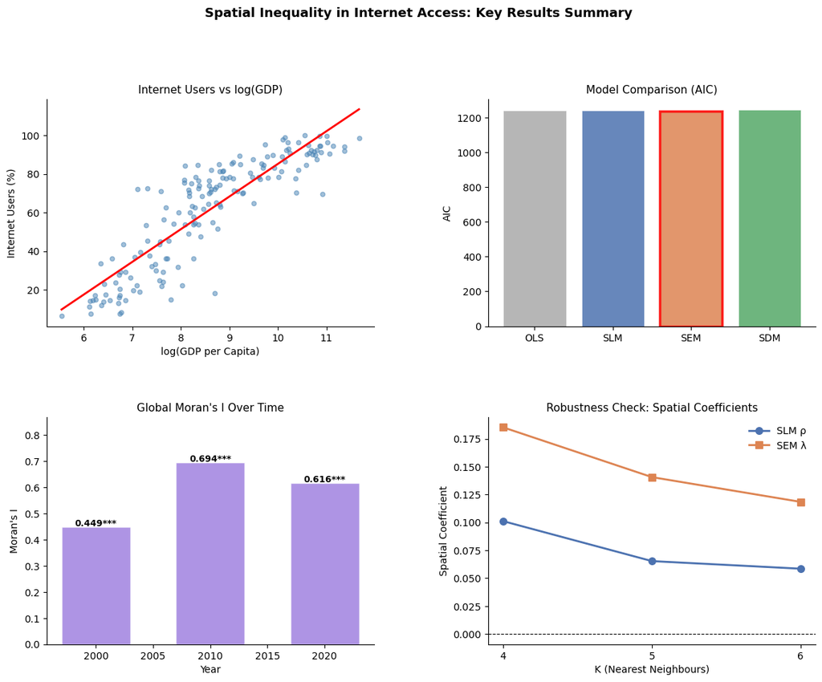

```
Figure 11 saved successfully
```

```python
fig = plt.figure(figsize=(14, 10))
gs  = gridspec.GridSpec(2, 2, figure=fig, hspace=0.4, wspace=0.35)

#Top left: Scatter plot of partial regression of the three variables against internet_users
ax1.scatter(reg_df['log_gdp'], reg_df['internet_users'],
            alpha=0.5, s=20, color='steelblue')
m, b = np.polyfit(reg_df['log_gdp'], reg_df['internet_users'], 1)
x_line = np.linspace(reg_df['log_gdp'].min(), reg_df['log_gdp'].max(), 100)
ax1.plot(x_line, m * x_line + b, color='red', lw=2)
ax1.set_xlabel('log(GDP per Capita)', fontsize=10)
ax1.set_ylabel('Internet Users (%)', fontsize=10)
ax1.set_title('Internet Users vs log(GDP)', fontsize=11)
ax1.spines[['top','right']].set_visible(False)

# Top right: Model AIC comparison bar chart
ax2 = fig.add_subplot(gs[0, 1])
model_names = ['OLS', 'SLM', 'SEM', 'SDM']
aics = [ols.aic, slm.aic, sem.aic, sdm.aic]
bar_colors = ['#aaaaaa','#4C72B0','#DD8452','#55A868']
bars = ax2.bar(model_names, aics, color=bar_colors,
               edgecolor='white', linewidth=0.5, alpha=0.85)
ax2.set_ylabel('AIC', fontsize=10)
ax2.set_title('Model Comparison (AIC)', fontsize=11)
ax2.spines[['top','right']].set_visible(False)
best_aic_idx = np.argmin(aics)
bars[best_aic_idx].set_edgecolor('red')
bars[best_aic_idx].set_linewidth(2.5)

# Bottom left: Moran's I over time
ax3 = fig.add_subplot(gs[1, 0])
moran_years = list(moran_results.keys())
moran_Is    = [moran_results[y]['I'] for y in moran_years]
moran_ps    = [moran_results[y]['p'] for y in moran_years]
ax3.bar(moran_years, moran_Is, color='mediumpurple',
        alpha=0.75, edgecolor='white', width=6)
for yr, I, p in zip(moran_years, moran_Is, moran_ps):
    sig = '***' if p < 0.01 else '**' if p < 0.05 else '*' if p < 0.1 else ''
    ax3.text(yr, I + 0.003, f'{I:.3f}{sig}',
             ha='center', fontsize=9, fontweight='bold')
ax3.set_xlabel('Year', fontsize=10)
ax3.set_ylabel("Moran's I", fontsize=10)
ax3.set_title("Global Moran's I Over Time", fontsize=11)
ax3.spines[['top','right']].set_visible(False)
ax3.set_ylim(0, max(moran_Is) * 1.25)

# Bottom right: Robustness check (ρ vs. k)
ax4 = fig.add_subplot(gs[1, 1])
k_vals   = [4, 5, 6]
rho_vals = [0.1011, 0.0653, 0.0585]
lam_vals = [0.1852, 0.1406, 0.1184]
ax4.plot(k_vals, rho_vals, 'o-', color='#4C72B0', lw=2,
         markersize=7, label='SLM ρ')
ax4.plot(k_vals, lam_vals, 's-', color='#DD8452', lw=2,
         markersize=7, label='SEM λ')
ax4.axhline(0, color='black', lw=0.8, ls='--')
ax4.set_xlabel('K (Nearest Neighbours)', fontsize=10)
ax4.set_ylabel('Spatial Coefficient', fontsize=10)
ax4.set_title('Robustness Check: Spatial Coefficients', fontsize=11)
ax4.set_xticks(k_vals)
ax4.legend(frameon=False, fontsize=10)
ax4.spines[['top','right']].set_visible(False)

fig.suptitle('Spatial Inequality in Internet Access: Key Results Summary',
             fontsize=13, y=1.01, fontweight='bold')

plt.savefig('data/fig11_results_summary.png', dpi=150, bbox_inches='tight')
plt.show()
print("Figure 11 saved successfully")
```

# 6. Conclusion

First, global internet access exhibits significant and persistent spatial inequality. Although the global average penetration rate rose from 9.1% in 2000 to 63.6% in 2020, the gap between countries did not narrow proportionally. By 2020, internet penetration stood at approximately 87% in high-income countries versus 35% in low-income countries—a gap exceeding 50 percentage points—indicating that the digital divide is a structural feature of uneven global development rather than a transient diffusion phenomenon.

Second, internet access exhibits clear spatial autocorrelation. Global Moran's I values of 0.449, 0.694 and 0.616 in 2000, 2010 and 2020 (all p < 0.001) confirm systematic spatial clustering. North America and Europe form stable high-access cores, whilst sub-Saharan Africa constitutes a persistent low-access cluster. LISA analysis identifies 31 high-high and 35 low-low countries, confirming that digital inequality possesses a distinct spatial structure rather than a random distribution.

Fourth, the spatial structure of internet access is primarily mediated by the geographic agglomeration of economic and infrastructure variables rather than direct cross-border diffusion. After controlling for GDP, electricity and urbanisation, OLS residuals show no significant spatial autocorrelation. SEM achieves the lowest AIC and is identified as the optimal specification, suggesting that spatially correlated omitted factors—such as regional governance capacity or historical infrastructure path dependence—are the more likely drivers of spatial clustering.

This study has several limitations. National-level data may obscure within-country disparities, and the cross-sectional spatial framework limits causal identification. Future research could apply dynamic spatial panel models and incorporate sub-national data with multi-dimensional internet quality indicators for a more nuanced analysis of global digital inequality.

# References

Chinn, M.D. and Fairlie, R.W. (2007) 'The determinants of the global digital divide: A cross-country analysis of computer and internet penetration', *Oxford Economic Papers*, 59(1), pp. 16–44.

Vicente, M.R. and López, A.J. (2011) 'Assessing the regional digital divide across the European Union-27', *Telecommunications Policy*, 35(3), pp. 220–237.